# Imputation

Dongneuck Lee 730263510

4/19/2020

```r
#library(data.table)
data <- fread("bank-additional/bank-additional/bank-additional-full.csv")
```

## looking into data

```r
#View(data)
names(data)
```

```
##  [1] "age"            "job"            "marital"        "education"
##  [5] "default"        "housing"        "loan"           "contact"
##  [9] "month"          "day_of_week"    "duration"       "campaign"
## [13] "pdays"          "previous"       "poutcome"       "emp.var.rate"
## [17] "cons.price.idx" "cons.conf.idx"  "euribor3m"      "nr.employed"
## [21] "y"
```

```r
dplyr::glimpse(data)
```

```
## Observations: 41,188
## Variables: 21
## $ age            <int> 56, 57, 37, 40, 56, 45, 59, 41, 24, 25, 41, 25, 29, ...
## $ job            <chr> "housemaid", "services", "services", "admin.", "serv...
## $ marital        <chr> "married", "married", "married", "married", "married...
## $ education      <chr> "basic.4y", "high.school", "high.school", "basic.6y"...
## $ default        <chr> "no", "unknown", "no", "no", "no", "unknown", "no", ...
## $ housing        <chr> "no", "no", "yes", "no", "no", "no", "no", "no", "ye...
## $ loan           <chr> "no", "no", "no", "no", "yes", "no", "no", "no", "no...
## $ contact        <chr> "telephone", "telephone", "telephone", "telephone", ...
## $ month          <chr> "may", "may", "may", "may", "may", "may", "may", "ma...
## $ day_of_week    <chr> "mon", "mon", "mon", "mon", "mon", "mon", "mon", "mo...
## $ duration       <int> 261, 149, 226, 151, 307, 198, 139, 217, 380, 50, 55,...
## $ campaign       <int> 1, 1, 1, 1, 1, 1, 1, 1, 1, 1, 1, 1, 1, 1, 1, 1, 1, 1...
## $ pdays          <int> 999, 999, 999, 999, 999, 999, 999, 999, 999, 999, 99...
## $ previous       <int> 0, 0, 0, 0, 0, 0, 0, 0, 0, 0, 0, 0, 0, 0, 0, 0, 0, 0...
## $ poutcome       <chr> "nonexistent", "nonexistent", "nonexistent", "nonexi...
## $ emp.var.rate   <dbl> 1.1, 1.1, 1.1, 1.1, 1.1, 1.1, 1.1, 1.1, 1.1, 1.1, 1....
## $ cons.price.idx <dbl> 93.994, 93.994, 93.994, 93.994, 93.994, 93.994, 93.9...
## $ cons.conf.idx  <dbl> -36.4, -36.4, -36.4, -36.4, -36.4, -36.4, -36.4, -36...
## $ euribor3m      <dbl> 4.857, 4.857, 4.857, 4.857, 4.857, 4.857, 4.857, 4.8...
## $ nr.employed    <dbl> 5191, 5191, 5191, 5191, 5191, 5191, 5191, 5191, 5191...
## $ y              <chr> "no", "no", "no", "no", "no", "no", "no", "no", "no"...
```

```r
sum(is.na(data))  ## No missing?? Missing is coded with "unknown". Also, this data is imbalanced because
```

```
## [1] 0
```

```r
sum(data$y == "yes") / nrow(data)
```

```
## [1] 0.1126542
```

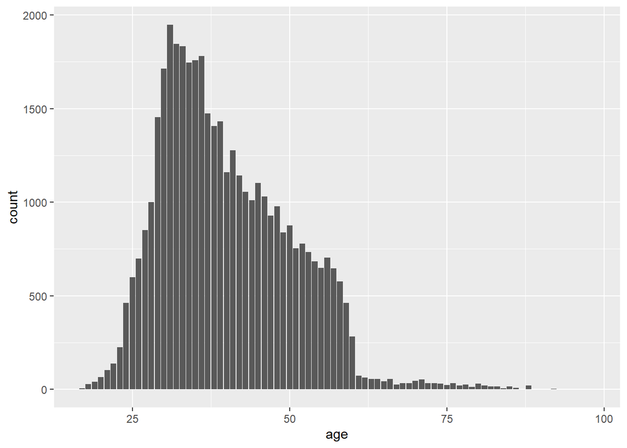

```r
# as.factor
data$job         <- as.factor(data$job)
data$marital     <- as.factor(data$marital)
data$education   <- as.factor(data$education)
data$default     <- as.factor(data$default)
data$housing     <- as.factor(data$housing)
data$loan        <- as.factor(data$loan)
data$contact     <- as.factor(data$contact)
data$month       <- as.factor(data$month)
data$day_of_week <- as.factor(data$day_of_week)
data$poutcome    <- as.factor(data$poutcome)
data$y           <- as.factor(data$y)


#library(tidyverse)
data.test <- data

ggplot(data=data.test) + geom_bar(aes(x=age)) ## no unknown
```

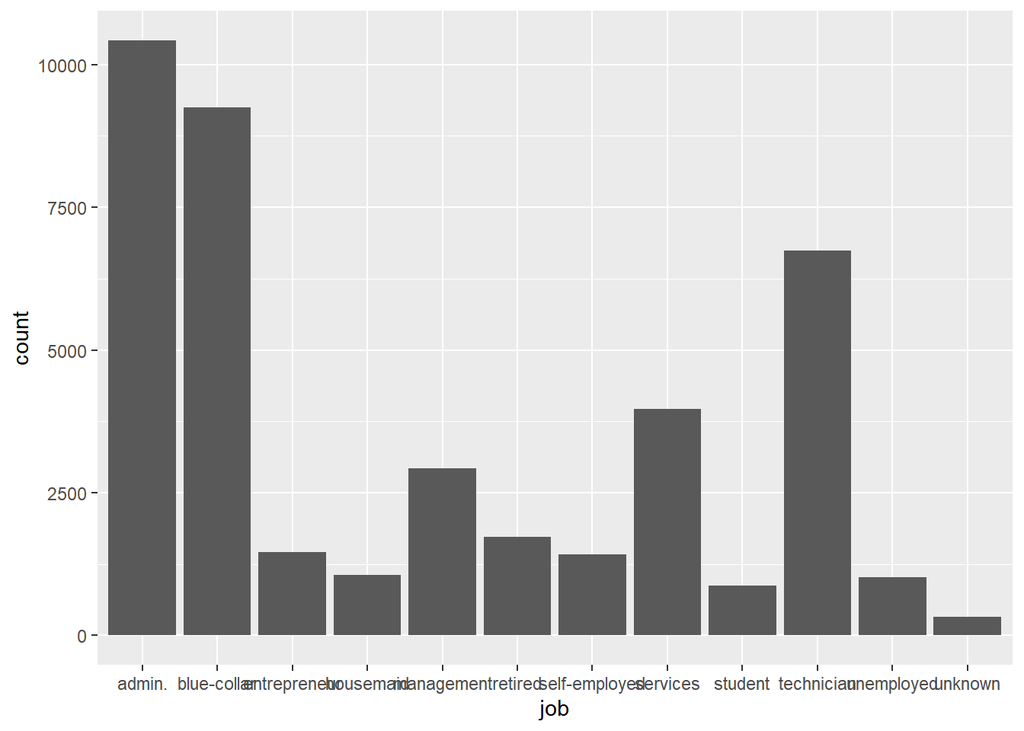

```r
ggplot(data=data.test) + geom_bar(aes(x=job)) ## small unknown
```

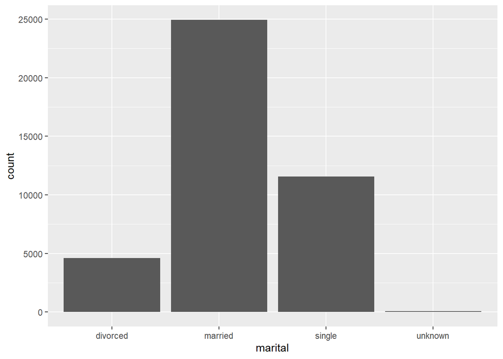

```r
ggplot(data=data.test) + geom_bar(aes(x=marital)) ## small unknown
```

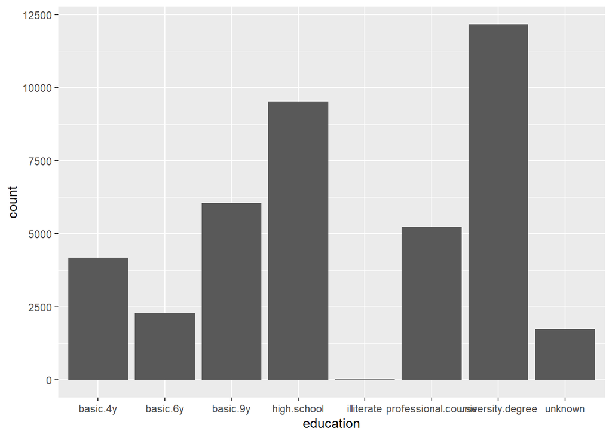

```r
ggplot(data=data.test) + geom_bar(aes(x=education)) ## small unknown
```

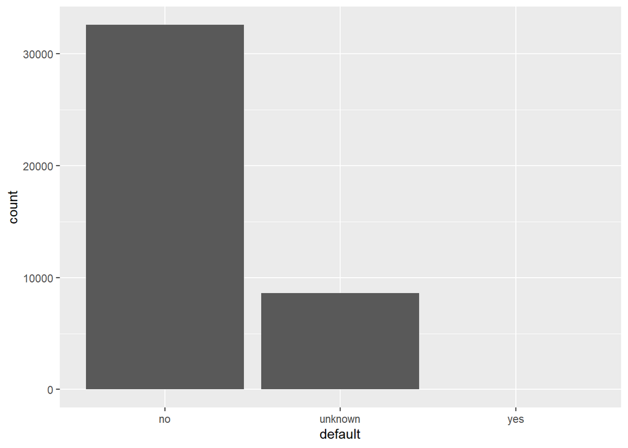

```r
ggplot(data=data.test) + geom_bar(aes(x=default)) ## some unknown
```

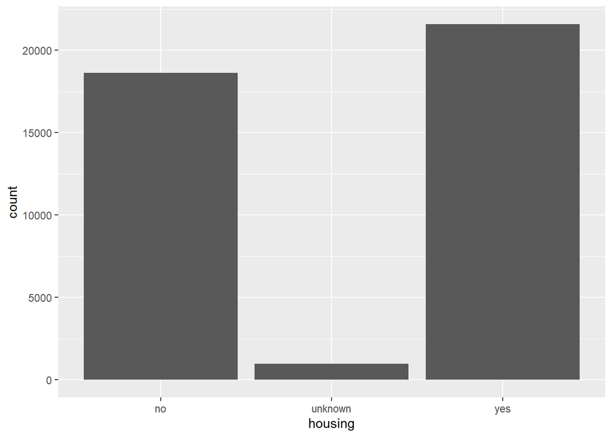

```r
ggplot(data=data.test) + geom_bar(aes(x=housing)) ## some unknown
```

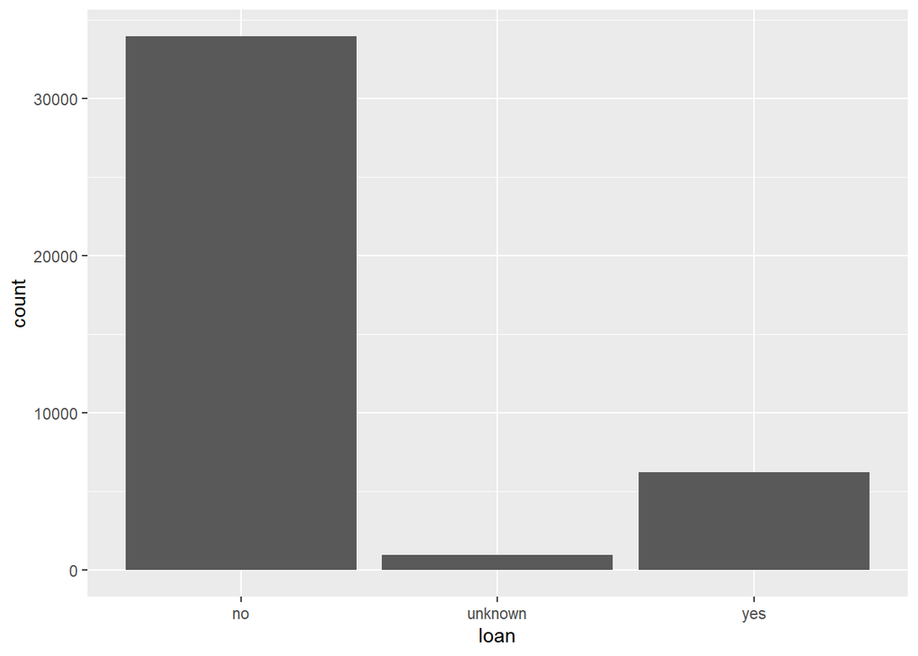

```r
ggplot(data=data.test) + geom_bar(aes(x=loan)) ## some unknown
```

Following variables don’t have missing value

```r
ggplot(data=data.test) + geom_bar(aes(x=contact)) ## no unknown
ggplot(data=data.test) + geom_bar(aes(x=month)) ## no unknown
ggplot(data=data.test) + geom_bar(aes(x=day_of_week)) ## no unknown
ggplot(data=data.test) + geom_bar(aes(x=duration)) ## no unknown

ggplot(data=data.test) + geom_bar(aes(x=campaign)) ## no unknown
ggplot(data=data.test) + geom_bar(aes(x=pdays))    ## no unknown// 999 means client was not previously contacted)
  data.test %>%
    filter(pdays < 50) %>%
    ggplot() + geom_bar(aes(x=pdays))
ggplot(data=data.test) + geom_bar(aes(x=previous)) ## no unknown
ggplot(data=data.test) + geom_bar(aes(x=poutcome)) ## assume no unknown

ggplot(data=data.test) + geom_bar(aes(x=emp.var.rate)) ## no unknown
ggplot(data=data.test) + geom_bar(aes(x=cons.price.idx)) ## no unknown
ggplot(data=data.test) + geom_bar(aes(x=cons.conf.idx))  ## no unknown
ggplot(data=data.test) + geom_bar(aes(x=euribor3m))      ## no unknown
ggplot(data=data.test) + geom_bar(aes(x=nr.employed))    ## no unknown

ggplot(data=data.test) + geom_bar(aes(x=y))  ## no unknown
```

[output not shown]

I think we don’t need the variables ‘month’ and ‘day_of_week’ indicating the last contact day.

1 999 in `pdays` means client was not previously contacted. I think setting this 0 instead of 999 might be better. It depends on the model we choose.

Only categorical variables has unknown

```r
data.test <- data.test[,-c(9, 10)]  ## remove 'month' and 'day_of_week'
```

```r
#library(naniar)
sum(data.test=="unknown", na.rm = T)
```

```
## [1] 12718
```

This dataset has 12,718 missing values coded with “unknown”. Let’s replace them with NA’s

```r
data.test <- data.test %>%
  replace_with_na(replace = list(job="unknown", marital="unknown", education="unknown",
                                 default="unknown", housing="unknown", loan="unknown"))
sum(data.test=="unknown", na.rm = T) #double check
```

```
## [1] 0
```

# Simulation

Before iputing NA’s, we need to check which method imputes missings “better”. There are two candidates, missForest and MICE. To campare them, I will generate fake missing and apply the candidates. The measurement will be proportion of falsely classified entries (PFC) over the categorical missing values.

This is the simulation step.

1. Extract rows without any missing. This data is called `complete`
2. For each colums, substitute elemets with NA (artificially produce missing values). Since we want the generated simluation data to be similar to the whole data as much as possible, the proportion of NA will be that of full data set. For example, job variables has missing at a rate of 0.8%. Therefore, seed NA’s in `complete` at a rate of 0.8%.
3. Repeat step2 five times. Then five simulation dataset is generated. Let’s call them `sim1`, …, `sim5`
4. Apply missForest and MICE to `sim1`, …, `sim5` and obtain PFC’s.
5. Check which method has smaller PFC’s.

```r
# Complete data
complete <- data.test[complete.cases(data.test), ]
sum(is.na(complete))
```

```
## [1] 0
```

```r
# Artificially produce missing values using the 'prodNA' function (simulation purpose)
#library(missForest)
n <- nrow(data.test)

set.seed(1)
sim1 <- complete
sim1$job       <- prodNA( data.frame(job=complete$job) , sum(is.na(data.test$job))/ n)
sim1$marital   <- prodNA( data.frame(marital=complete$marital) , sum(is.na(data.test$marital))/ n)
sim1$education <- prodNA( data.frame(education=complete$education) , sum(is.na(data.test$education))/ n)
sim1$default   <- prodNA( data.frame(default=complete$default) , sum(is.na(data.test$default))/ n)
sim1$housing   <- prodNA( data.frame(housing=complete$housing) , sum(is.na(data.test$housing))/ n)
sim1$loan      <- prodNA( data.frame(loan=complete$loan) , sum(is.na(data.test$loan))/ n)


set.seed(2)
sim2 <- complete
sim2$job       <- prodNA( data.frame(job=complete$job) , sum(is.na(data.test$job))/ n)
sim2$marital   <- prodNA( data.frame(marital=complete$marital) , sum(is.na(data.test$marital))/ n)
sim2$education <- prodNA( data.frame(education=complete$education) , sum(is.na(data.test$education))/ n)
sim2$default   <- prodNA( data.frame(default=complete$default) , sum(is.na(data.test$default))/ n)
sim2$housing   <- prodNA( data.frame(housing=complete$housing) , sum(is.na(data.test$housing))/ n)
sim2$loan      <- prodNA( data.frame(loan=complete$loan) , sum(is.na(data.test$loan))/ n)


set.seed(3)
sim3 <- complete
sim3$job       <- prodNA( data.frame(job=complete$job) , sum(is.na(data.test$job))/ n)
sim3$marital   <- prodNA( data.frame(marital=complete$marital) , sum(is.na(data.test$marital))/ n)
sim3$education <- prodNA( data.frame(education=complete$education) , sum(is.na(data.test$education))/ n)
sim3$default   <- prodNA( data.frame(default=complete$default) , sum(is.na(data.test$default))/ n)
sim3$housing   <- prodNA( data.frame(housing=complete$housing) , sum(is.na(data.test$housing))/ n)
sim3$loan      <- prodNA( data.frame(loan=complete$loan) , sum(is.na(data.test$loan))/ n)


set.seed(4)
sim4 <- complete
sim4$job       <- prodNA( data.frame(job=complete$job) , sum(is.na(data.test$job))/ n)
sim4$marital   <- prodNA( data.frame(marital=complete$marital) , sum(is.na(data.test$marital))/ n)
sim4$education <- prodNA( data.frame(education=complete$education) , sum(is.na(data.test$education))/ n)
sim4$default   <- prodNA( data.frame(default=complete$default) , sum(is.na(data.test$default))/ n)
sim4$housing   <- prodNA( data.frame(housing=complete$housing) , sum(is.na(data.test$housing))/ n)
sim4$loan      <- prodNA( data.frame(loan=complete$loan) , sum(is.na(data.test$loan))/ n)


set.seed(5)
sim5 <- complete
sim5$job       <- prodNA( data.frame(job=complete$job) , sum(is.na(data.test$job))/ n)
sim5$marital   <- prodNA( data.frame(marital=complete$marital) , sum(is.na(data.test$marital))/ n)
sim5$education <- prodNA( data.frame(education=complete$education) , sum(is.na(data.test$education))/ n)
sim5$default   <- prodNA( data.frame(default=complete$default) , sum(is.na(data.test$default))/ n)
sim5$housing   <- prodNA( data.frame(housing=complete$housing) , sum(is.na(data.test$housing))/ n)
sim5$loan      <- prodNA( data.frame(loan=complete$loan) , sum(is.na(data.test$loan))/ n)
```